# Counterfactual DM in maltreated kids: Analyze Data

Inge Huijsmans

### Task and data information

*Task: Counterfactual Decision Making*  
Baskin-Sommers, A., Stuppy-Sullivan, A. M., & Buckholtz, J. W. (2016). Psychopathic individuals exhibit but do not avoid regret during counterfactual decision making. Proceedings of the National Academy of Sciences, 113(50), 14438-14443.

*Link to task:*  
http://snplab.fas.harvard.edu/adcf/  
Note. If you do the task use your own name as subject number (NO DIGITS). This way we can never confuse pilot data with participant data.

*Links to data:*  
usern: sdlab  
passw: stressDEV1  
http://snplab.fas.harvard.edu/adcf/data  
http://snplab.fas.harvard.edu/adcfremote/data

*Google drive folder Frankie & Mahalia:*  
https://drive.google.com/drive/folders/100at88UR1CjjLLPHCn1el5LpHb7WwfTs

#### Things that stood out during analysis:

- Some participants never adjust their first affect rating in the second affect rating or very rarely. This might be an artifact of the experiment program. After submitting affect rating 1, this value is saved and used as start point for affect rating 2. Therefore, participants could make it an easy strategy not to change affect rating 1. Five participants never change affect rating 1. Our main interest in this task are the affect ratings. Will we keep these participants in the data for analysis?

# Let’s go!

#### Setup some R things

```r
options(repos = c(CRAN = "http://cran.rstudio.com"))
#install.packages('lme4', dependencies=TRUE, repos='https://ftp.ussg.iu.edu/CRAN/')


require(plyr)      # for ddply()
require(ggplot2)
require(tidyr)     #for long to wide, gather & spread <3
require(tidyverse)

require(emmeans)
require(lme4)
require(lmerTest)
require(afex)


options(digits=20)
#loadfonts(device="win")

rm(list=ls())


#Set wd Harvard
#wd <- '/Users/ingehuijsmans/OneDrive - Harvard University/KidsDecision/'
#Set wd Wageningen
wd <- '/Users/rhmhuijsmans/inge/OneDrive - Harvard University/KidsDecision/'
dataDir <- paste(wd, 'data/csv/', sep = '')
analysesDir <- paste(wd, 'analyses/', sep = '')
plotsDir <- paste(wd, 'plots/', sep = '')

#Function for axis rounding
twoDecimals <- function(x) sprintf("%.2f", x)

#Set colors
fivecolors <- c('#003f5c','#58508d','#bc6090','#ff6361','#ffa600')
twocolors <- fivecolors[c(2,4)]
sevencolors <- c('#C70039','#FF5733', '#FF8D1A','#FFC300', '#EDDD53', '#ADD45C','#57C785')

#Load & save environment data
load(paste(analysesDir,'/dataClean.Rdata', sep = ''))

#save.image(paste(analysesDir,'/workspace.Rdata', sep = ''))

#Remove participants that were selected in dataClean.Rmd
data <- subset(dataClean, removeSubjects == 'no')
```

## Let’s do some sanity checks with plots

1. Are participants happier when they get more money?  
   Test: Outcome ~ affect rating 1  
   Outcome: From visual inspection you can see that with increasing offer participants report to have more positive affect. This seems to be a nice linear effect

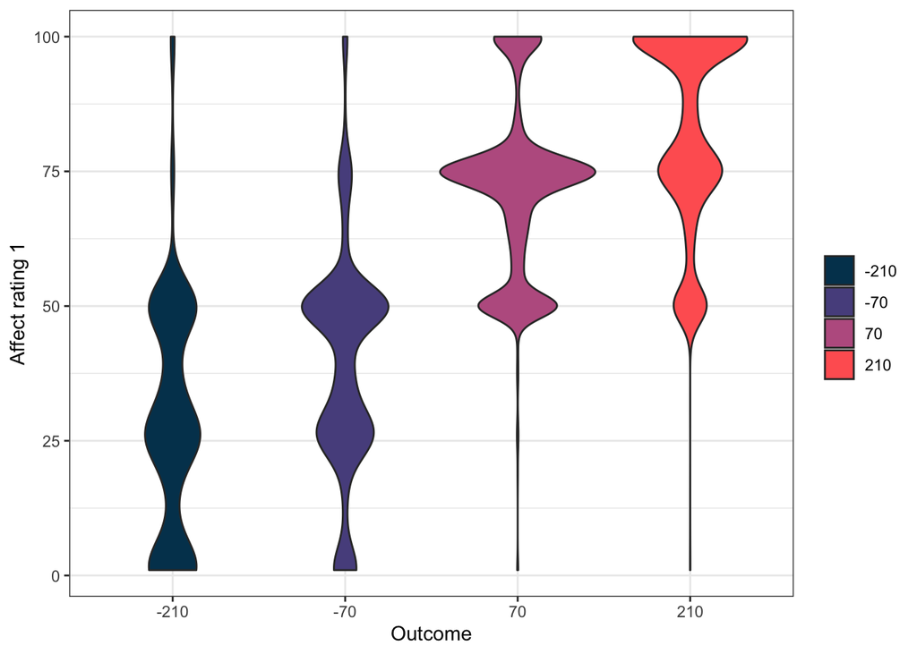

```r
data$f_outcomeChoice <- factor(data$outcomeChoice)
ggplot(data, aes(f_outcomeChoice, affect1, fill = f_outcomeChoice)) +
  geom_violin() +
  scale_fill_manual(values = fivecolors) +
  theme_bw() + labs(x = 'Outcome', y = 'Affect rating 1', fill = '')
```

2. Are participants still happier when they get more money after knowing what they could have had?  
   **Test:** Outcome ~ affect rating 2  
   **Outcome:** Again, from visual inspection you can see that with increasing offer participants report to have more positive affect. This seems to be a nice linear effect. Maybe a bit more variace than affect rating 1.

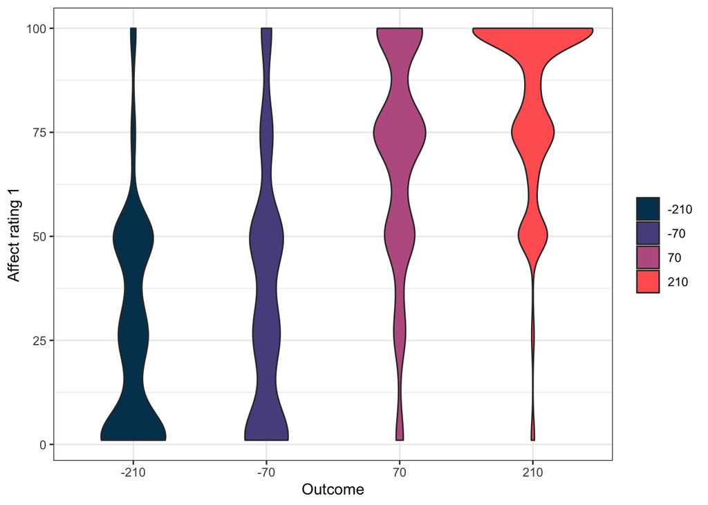

```r
ggplot(data, aes(f_outcomeChoice, affect2, fill = f_outcomeChoice)) +
  geom_violin() +
  scale_fill_manual(values = fivecolors) +
  theme_bw() + labs(x = 'Outcome', y = 'Affect rating 1', fill = '')
```

Counterfactual thinking is based on the idea that people feel regret when they see the outcome that they could have had, precisely “an aversive emotional state that is elicited by adiscrepancy in the outcome values of chosen vs. unchosen actions.” (from buckholtz, 2016, PNAS). This leads to my second hypothesis/check:

2. Participants should update their affect rating 1 from rating 2. Do participants do this?

**Test:** affect1 - affect2 > 0 **Outcome:** Well… It seems that participants don’t really change their affect ratings that much.. Let’s explore further, make a note of this and discuss with Josh.

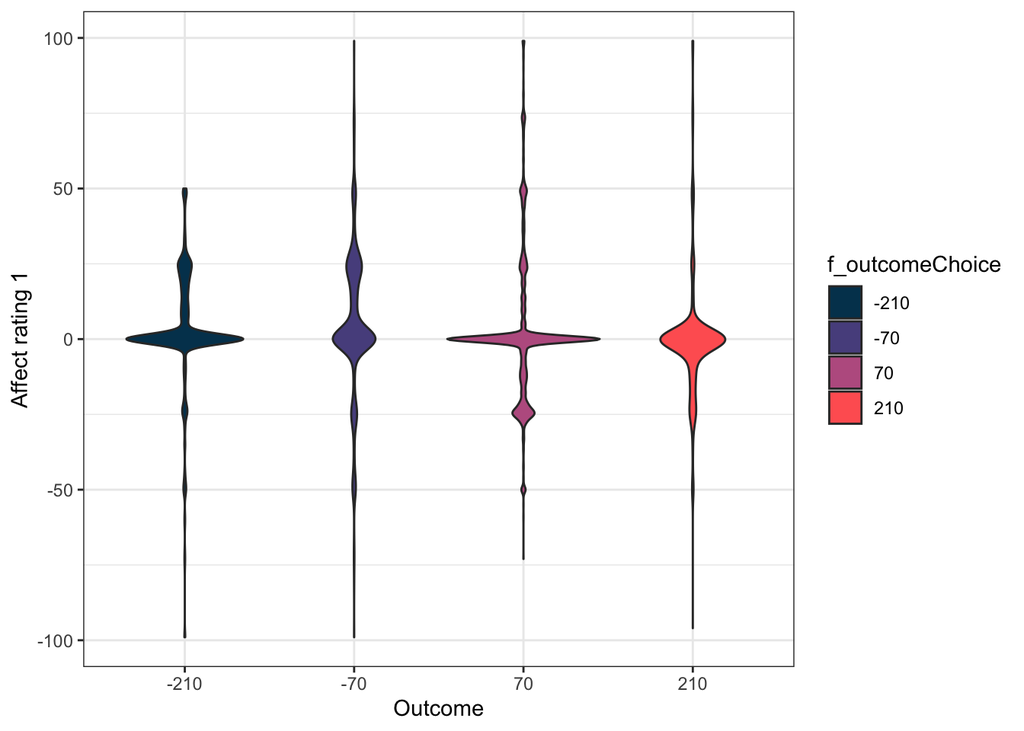

```r
data$changeAffect <- data$affect1 - data$affect2
ggplot(data, aes(f_outcomeChoice, changeAffect, fill = f_outcomeChoice)) +
  geom_violin() +
  scale_fill_manual(values = fivecolors) +
  theme_bw() + labs(x = 'Outcome', y = 'Affect rating 1')
```

Next, I want to see if keeping affect rating 2 the same compared to affect rating 1 is a common strategy.

It seems that this is quite a common strategy. That seems problematic to me.  
5 participants never changed affect rating 1.  
18 particpants changed their affect rating in less than 10% of the trials.

```r
#Are there participants that never change the rating?
notchanged <- data.frame(table(subset(data, changeAffect == 0)$subject))
names(notchanged) <- c('subject','freq')

#5 participants never changed their second affect rating. What was their affect?
nrow(notchanged[notchanged$freq == 55,])
```

```
## [1] 5
```

```r
#18 participants changed their affect rating in less than 10% of trials
nrow(notchanged[notchanged$freq > 55*0.9,])
```

```
## [1] 18
```

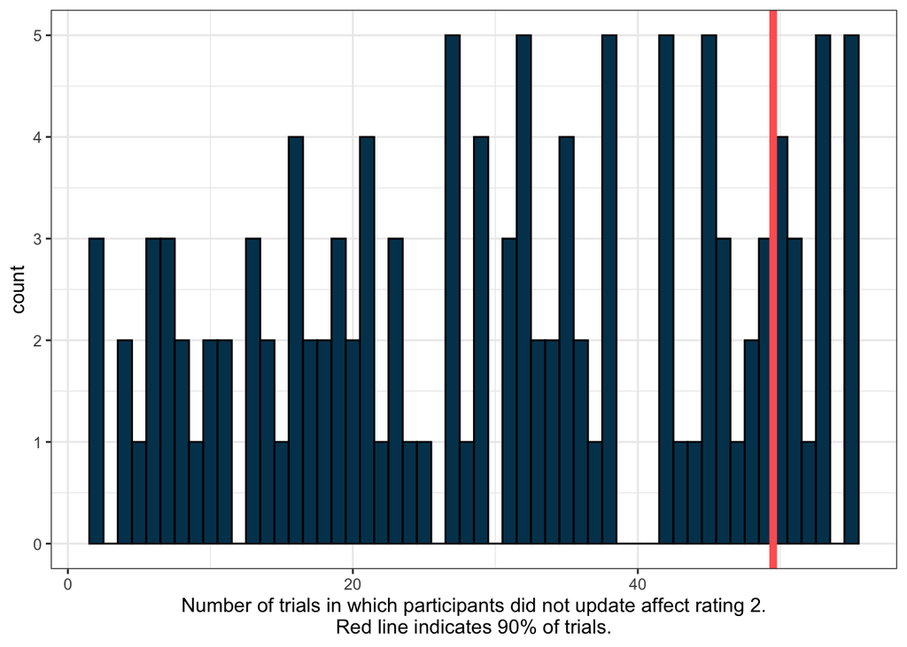

```r
#Save subject numbers
noAffectChangeSubs <- notchanged[notchanged$freq == 55,]$subject
noAffectChangeSubs90 <- notchanged[notchanged$freq > 55*0.9 & notchanged$freq != 55,]$subject

#Distribution
ggplot(notchanged, aes(freq)) + geom_histogram(binwidth = 1, color = 'black', fill = fivecolors[1]) +
  theme_bw() + labs(x = 'Number of trials in which participants did not update affect rating 2.\nRed line indicates 90% of trials.') +
  geom_vline(xintercept = 49.5, size = 2, color = fivecolors[4])
```

How bad does that look for the individual participants. Did they learn that this is the easy way out?

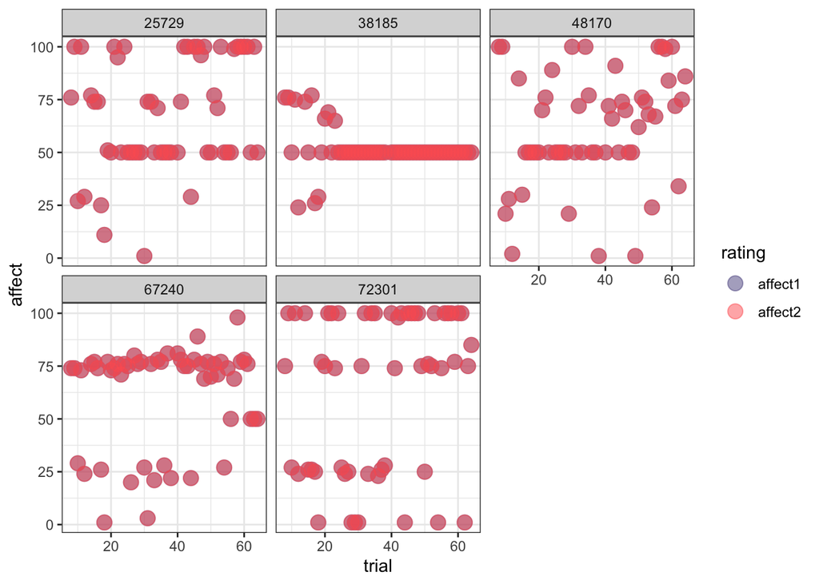

```r
#How does that data look like for these participants?
#This seems very strange... There is a lot of variability in the ratings but the numbers are exactly the same. Does this happen for all participants?
#Is there something different about the data collection of these participants?

noAffectChangeDF_L <- gather(subset(data, select = c('subject','trial','affect1','affect2')), rating, affect, affect1:affect2)

#Particpants who never adapted that rating
ggplot(subset(noAffectChangeDF_L, subject %in% noAffectChangeSubs), aes(trial, affect, color = rating)) +
  facet_wrap(~subject, ncol = 3) +
  geom_point(alpha = 0.5, size = 4) + scale_color_manual(values = twocolors) + theme_bw()
```

participants who adapted their affect rating in less than 10% of trials

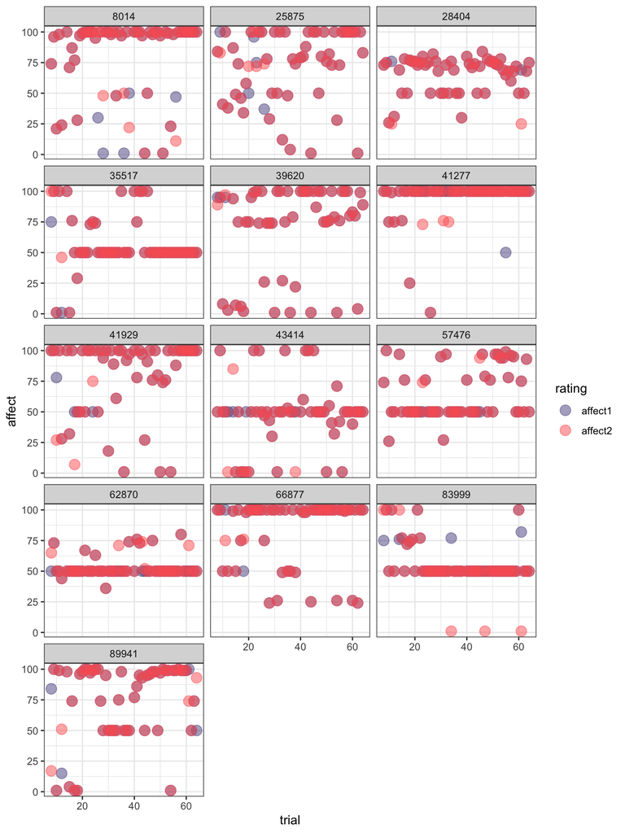

```r
ggplot(subset(noAffectChangeDF_L, subject %in% noAffectChangeSubs90), aes(trial, affect, color = rating)) +
  facet_wrap(~subject, ncol = 3) +
  geom_point(alpha = 0.5, size = 4) + scale_color_manual(values = twocolors) + theme_bw()
```

Did EV predict choice?

```r
install.packages('tidyverse')
```

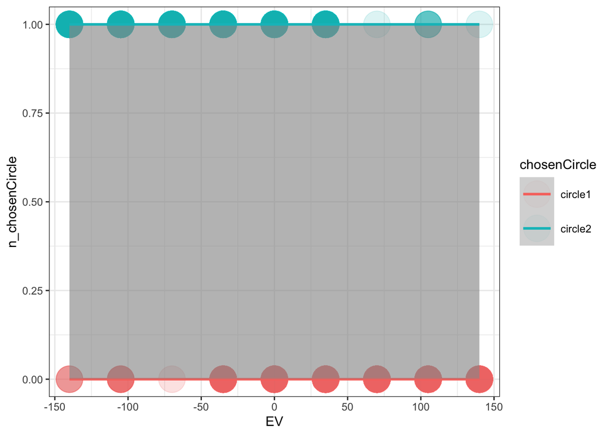

```r
require(tidyverse)
data$n_chosenCircle <- as.numeric(data$chosenCircle)-2
ggplot(data, aes(EV, n_chosenCircle, color = chosenCircle)) + geom_point(size = 10, alpha = 0.05) +
  stat_smooth(method="glm", method.args=list(family="binomial"), se=TRUE)+
  theme_bw()
```

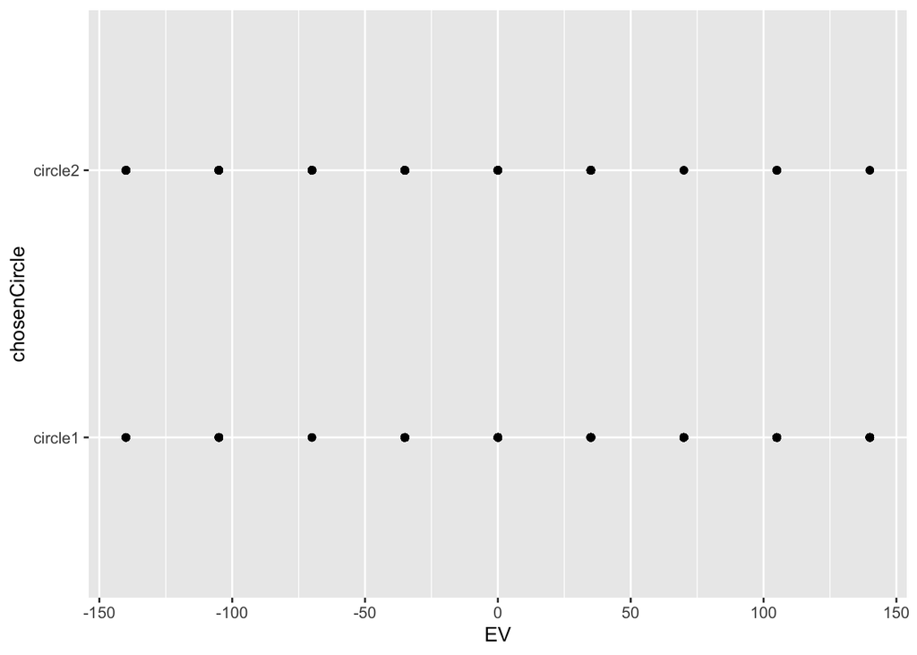

```r
ggplot(data, aes(x=EV, y=chosenCircle)) + geom_point() +
  stat_smooth(method="glm", method.args=list(family="binomial"), se=TRUE)
```